# Access Arm Treasure Data from R with RPresto and RTD

This is an example notebook to connect Arm Treasure Data (TD) from R. If you want to know how to access from R with RJDBC or RPresto, you can see [How to connect Arm Treasure Data from R](https://rpubs.com/chezou/TD-from-R).

While RPresto enables you to query TD easily, it can’t handle some TD execution. In this notebook, I will explain how to query with RPresto and how to execute basic TD operation.

If you want to use [embulk](https://www.embulk.org/) and embulk-output-td plugin, ensure PATH for `embulk` command to be set appropriately.

You also have to set your “TD_API_KEY” is set as an environement variable.

Let’s install RPresto and RTD packages.

```r
install.packages(c("RPresto", "RTD", "dplyr", "dbplyr", "ggplot2"))
```

We will use nycflights13 package for analysis. Copy flights data to TD.

```r
install.packages("nycflights13")
```

```r
library(RTD)

client <- Td(apikey = Sys.getenv("TD_API_KEY"), endpoint="api.treasuredata.com")
td_upload(client, "test", "flights", nycflights13::flights, overwrite=T)
```

```
## Created bulk import session
```

```
## Created msgpack file
```

```
## Start uploading bulk import part file
```

```
## Freezing bulk import
```

```
## Performing bulk import
```

```
## Commiting bulk import
```

```
## Finished bulk import
```

If you want to use embulk for `td_upload`, you can set `mode="embulk"` like:

```r
td_upload(client, "test", "flights", nycflights13::flights, mode="embulk", overwrite=T)
```

Then, connect the table with RPresto.

```r
library(RPresto)
library(dplyr)
db <- src_presto(
  host="https://api-presto.treasuredata.com",
  port=443,
  user=Sys.getenv("TD_API_KEY"),
  schema='test',
  catalog='td-presto'
)

flights_tbl <- tbl(db, 'flights')
```

Execute simple dplyr operation.

```r
# filter by departure delay
flights_tbl %>% filter(dep_delay == 2)
```

| year | month | day | dep_time | sched_dep_time | dep_delay | arr_time | sched_arr_time | arr_delay | carrier | flight | tailnum | origin | dest | air_time | distance | hour | minute | time_hour | time |
| --- | --- | --- | --- | --- | --- | --- | --- | --- | --- | --- | --- | --- | --- | --- | --- | --- | --- | --- | --- |
| 2013 | 9 | 30 | 1610 | 1608 | 2 | 1729 | 1752 | -23 | B6 | 1105 | N306JB | JFK | ORD | 111 | 740 | 16 | 8 | 1380571200 | 1595815532 |
| 2013 | 9 | 30 | 1621 | 1619 | 2 | 1856 | 1919 | -23 | B6 | 283 | N632JB | JFK | MCO | 129 | 944 | 16 | 19 | 1380571200 | 1595815532 |
| 2013 | 9 | 30 | 1702 | 1700 | 2 | 1940 | 1921 | 19 | DL | 2042 | N346NB | EWR | ATL | 99 | 746 | 17 | 0 | 1380574800 | 1595815532 |
| 2013 | 9 | 30 | 1731 | 1729 | 2 | 2008 | 2030 | -22 | UA | 1692 | N36472 | EWR | SAN | 302 | 2425 | 17 | 29 | 1380574800 | 1595815532 |
| 2013 | 9 | 30 | 952 | 950 | 2 | 1203 | 1220 | -17 | VX | 251 | N846VA | JFK | LAS | 287 | 2248 | 9 | 50 | 1380546000 | 1595815532 |
| 2013 | 9 | 30 | 1002 | 1000 | 2 | 1149 | 1120 | 29 | US | 2175 | N748UW | LGA | DCA | 44 | 214 | 10 | 0 | 1380549600 | 1595815532 |
| 2013 | 9 | 30 | 1146 | 1144 | 2 | 1425 | 1429 | -4 | UA | 1519 | N17105 | EWR | MCO | 130 | 937 | 11 | 44 | 1380553200 | 1595815532 |
| 2013 | 9 | 30 | 1337 | 1335 | 2 | 1444 | 1500 | -16 | WN | 1 | N7704B | LGA | MDW | 103 | 725 | 13 | 35 | 1380560400 | 1595815532 |
| 2013 | 9 | 30 | 1357 | 1355 | 2 | 1547 | 1615 | -28 | WN | 246 | N430WN | EWR | PHX | 267 | 2133 | 13 | 55 | 1380560400 | 1595815532 |
| 2013 | 9 | 30 | 742 | 740 | 2 | 852 | 900 | -8 | MQ | 3709 | N537MQ | EWR | ORD | 97 | 719 | 7 | 40 | 1380538800 | 1595815532 |

[output cut: 990 more lines]

[“Introduction to dplyr”](https://cran.r-project.org/web/packages/dplyr/vignettes/dplyr.html) introduces advanced dplyr examples. Let’s try grouped operations example from the tutorial and plot the result.

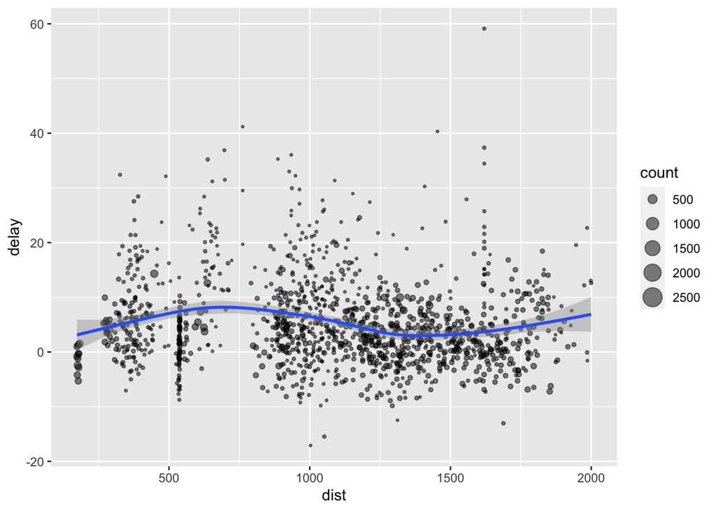

```r
delay <- flights_tbl %>%
  group_by(tailnum) %>%
  summarise(count = n(), dist = mean(distance, na.rm = TRUE), delay = mean(arr_delay, na.rm = TRUE)) %>%
  filter(count > 20, dist < 2000) %>%
  collect

# plot delays
library(ggplot2)
ggplot(delay, aes(dist, delay)) +
  geom_point(aes(size = count), alpha = 1/2) +
  geom_smooth() +
  scale_size_area()
```

You can write SQL using `DBI` package.

```r
library(DBI)

con <- dbConnect(
  RPresto::Presto(),
  host="https://api-presto.treasuredata.com",
  port=443,
  user=Sys.getenv("TD_API_KEY"),
  schema='test',
  catalog='td-presto'
)

flights_preview <- dbGetQuery(con, 'SELECT year, month, day, dep_time, dep_delay, carrier, flight from flights limit 10')
flights_preview
```

| year | month | day | dep_time | dep_delay | carrier | flight |
| --- | --- | --- | --- | --- | --- | --- |
| 2013 | 9 | 30 | 1759 | 29 | WN | 19 |
| 2013 | 9 | 30 | 1759 | 4 | UA | 691 |
| 2013 | 9 | 30 | 1759 | -4 | UA | 775 |
| 2013 | 9 | 30 | 1802 | 27 | AA | 2351 |
| 2013 | 9 | 30 | 1802 | 57 | B6 | 408 |
| 2013 | 9 | 30 | 1802 | -3 | UA | 1139 |
| 2013 | 9 | 30 | 1805 | -10 | DL | 2019 |
| 2013 | 9 | 30 | 1805 | -10 | 9E | 3513 |
| 2013 | 9 | 30 | 1807 | 12 | DL | 1629 |
| 2013 | 9 | 30 | 1810 | -5 | UA | 1022 |

You can execute basic TD operation like delete table.

```r
delete_table(client, "test", "flights")
```

```
## [1] TRUE
```

## References

- RPresto
- RTD